# Scheduling disciplines for the G/G/k queue Évaluation de Performances 2024, DM, INFO4, Polytech Grenoble

ARLE Alexandre - MIRAS Romain

2024-03-31

### A general code

The aim of this homework assignment is to be able to simulate and compare the dynamics of a G/G/k queue adopting a number of scheduling disciplines. The following code provides a basis for implementing and testing other scheduling disciplines.

```r
knitr::opts_chunk$set(echo = TRUE)

# This function plot the average response time of a M/G/1 queue for various scheduling disciplines.
# As input, it takes the number of servers (k), their job service times (Service) with their mean value (ES)
plot_response_times <- function(k, Service, ES){

  debug=0;
  scheduling_disciplines = c(1:4); # 'FCFS'=1,'LCFS'=2,'RO-S'=3,'SRPT'=4
  num_arrival_rates=5;
  lambdas = (1/ES) * c(1:num_arrival_rates)/(num_arrival_rates+1) ; # arrival rates

  # Matrix of average response times for all disciplines and arrival rates
  R_time <- matrix(0, nrow = length(scheduling_disciplines), ncol = length(lambdas));
  rownames(R_time) <- c("FCFS","LCFS","RO-S","SRPT");
  colnames(R_time) <- paste("rho=", round(lambdas*ES, digits = 3), sep = "");

  cnt=0;
  for (lambda in lambdas)
  {
    cnt=cnt+1;
    # Let's assume a Poisson process coming in, otherwise change the next line
    Arrival= cumsum(rexp(n=N, rate = lambda)); # Arrival times

    for (scheduling_discipline in scheduling_disciplines)
    {
      t = 0; # simulation time
      Remaining = rep(N, x=NA);    # Remaining service times of each job
      Completion = rep(N, x=NA);   # Completion time of each job

      AvgJobs = 0;
      CurrentTask = rep(k, x=NA); # Current task of each servers
      NextArrival = 1;
      while (TRUE) {

        if (debug==1){
          print("*********************");
          print(paste("Scheduling discipline = ",scheduling_discipline));
          print(Arrival);
          print(Service);
          print(Remaining);

        }

        dtA = NA;
        dtC = rep(k, x=NA);
        if(length(Arrival[Arrival>t])>0) { # if an arrival exists after t
          dtA = head(Arrival[Arrival>t],n=1)-t ; # time to next arrival
        }

        for (i in 1:k) {
          if(!is.na(CurrentTask[i])) { # if a task is running
            dtC[i] = Remaining[CurrentTask[i]]; # time to next completion
          }
        }

        if(is.na(dtA) & all(is.na(dtC))) {
          break; # no more arrivals and no more completions
        }

        minDtc = pmin(dtC,na.rm=T); # minimum time to completion between all servers
        dt = min(dtA,minDtc,na.rm=T); # time to next event

        # update system variables
        t = t + dt;
        AvgJobs=AvgJobs+dt*sum(!is.na(Remaining));

        if (debug==1){
          print(paste("Sim. time:", t));
          print(paste("# of jobs arrived: ", NextArrival));
        }
        # Job arrival

        if((NextArrival <=N) & (Arrival[NextArrival] == t)) {
          Remaining[NextArrival] = Service[NextArrival];
          NextArrival = NextArrival + 1;
        }



        # Job departure
        for (i in 1:k) {
          if(!is.na(CurrentTask[i])) {
            Remaining[CurrentTask[i]] = Remaining[CurrentTask[i]] - dt ;
            if(Remaining[CurrentTask[i]] <= 0) {
              # CurrentTask completed
              Completion[CurrentTask[i]] = t;
              Remaining[CurrentTask[i]] = NA;
              CurrentTask[i] = NA;
            }
          }
        }

        # Scheduling discipline
        WaitingListWithCurrentTask=(1:NextArrival)[!is.na(Remaining)]; # jobs that are waiting or running in the servers
        WaitingList = WaitingListWithCurrentTask[!WaitingListWithCurrentTask %in% CurrentTask]; # jobs that are waiting in the buffer

        if(length(WaitingList)>0) {

          # FCFS
          if (scheduling_discipline==1){
            for (i in 1:k) {
              if (is.na(CurrentTask[i])) {
                CurrentTask[i] = head(WaitingList,n=1);
                break;
              }
            }

          }

          # LCFS
          if (scheduling_discipline==2){
            # We implement the non-preemptive version of LCFS: jobs are never killed/resumed
            for (i in 1:k) {
              if(is.na(CurrentTask[i])) {
                # here, a task is not running, so we find a new job to serve
                CurrentTask[i] = tail(WaitingList,n=1);
                break;
              }
            }
          }

          # ROS: Random Order of Service
          if (scheduling_discipline==3){
            for (i in 1:k) {
              if(is.na(CurrentTask[i])) {
                # here, a task is not running, so we find a new job to serve
                if (length(WaitingList)>1) {
                  CurrentTask[i] = sample(WaitingList,size=1);
                } else{
                  CurrentTask[i] = WaitingList;
                }
                break;
              }
            }
          }

          # SRPT: Shortest Remaining Processing Time
          if (scheduling_discipline==4){
            for (i in 1:k) {
              if(is.na(CurrentTask[i])) {
                # here, a task is not running, so we find a new job to serve
                if (length(WaitingList)>1) {
                  CurrentTask[i] = WaitingList[which.min(Remaining[WaitingList])];
                } else{
                  CurrentTask[i] = WaitingList;
                }
                break;
              }
            }
          }

        }

        if (debug==1){
          print(CurrentTask)
          readline(prompt="Press [enter] to proceed")
        }

      } # while

      ResponseTime = mean(Completion-Arrival); #average response time
      AvgJobs=AvgJobs/(tail(Completion,n=1)-Arrival[1]); # average number of jobs in the system

      # Simulation completed. Let's verify Little law: N=lambda*R
      r_names=rownames(R_time)
      cat(paste("Sim. ",r_names[scheduling_discipline],"(rho=",round(lambda*ES,digits = 2),") completed."));
      cat(paste(" Little law verification: ", round(AvgJobs,digits = 4), "=N=lambda*R=", round(lambda*ResponseTime,digits = 4),"\n"));

      R_time[scheduling_discipline,cnt]=ResponseTime;

    } # loop scheduling discipline

  } # loop lambda

  cat("\nResponse time matrix:\n")
  print(R_time)

  matplot(t(R_time), type = "l", xlab="Load (lambda*E[S])", ylab="Avg Response Time", xaxt = "n", lwd = 3);
  legend("topleft", legend = rownames(R_time), col=1:4, pch=1);
  axis(side=1,at=1:ncol(R_time),labels=round(lambdas*ES, digits=3));

  return(R_time);
} # end function
```

### Let’s start slowly

We first simulate the dynamics induced by 10 arrivals with 3 servers in order to provide numerical evidence that our code is correct. We obtain:

```
## Sim.  FCFS (rho= 0.17 ) completed. Little law verification:  0.2645 =N=lambda*R= 0.2887
## Sim.  LCFS (rho= 0.17 ) completed. Little law verification:  0.2645 =N=lambda*R= 0.2887
## Sim.  RO-S (rho= 0.17 ) completed. Little law verification:  0.2645 =N=lambda*R= 0.2887
## Sim.  SRPT (rho= 0.17 ) completed. Little law verification:  0.2645 =N=lambda*R= 0.2887
## Sim.  FCFS (rho= 0.33 ) completed. Little law verification:  0.4167 =N=lambda*R= 0.5773
## Sim.  LCFS (rho= 0.33 ) completed. Little law verification:  0.4167 =N=lambda*R= 0.5773
## Sim.  RO-S (rho= 0.33 ) completed. Little law verification:  0.4167 =N=lambda*R= 0.5773
## Sim.  SRPT (rho= 0.33 ) completed. Little law verification:  0.4167 =N=lambda*R= 0.5773
## Sim.  FCFS (rho= 0.5 ) completed. Little law verification:  1.0984 =N=lambda*R= 0.866
## Sim.  LCFS (rho= 0.5 ) completed. Little law verification:  1.0984 =N=lambda*R= 0.866
## Sim.  RO-S (rho= 0.5 ) completed. Little law verification:  1.0984 =N=lambda*R= 0.866
## Sim.  SRPT (rho= 0.5 ) completed. Little law verification:  1.0984 =N=lambda*R= 0.866
## Sim.  FCFS (rho= 0.67 ) completed. Little law verification:  1.2378 =N=lambda*R= 1.2476
## Sim.  LCFS (rho= 0.67 ) completed. Little law verification:  1.194 =N=lambda*R= 1.2036
## Sim.  RO-S (rho= 0.67 ) completed. Little law verification:  1.2378 =N=lambda*R= 1.2476
## Sim.  SRPT (rho= 0.67 ) completed. Little law verification:  1.194 =N=lambda*R= 1.2036
## Sim.  FCFS (rho= 0.83 ) completed. Little law verification:  1.033 =N=lambda*R= 1.4434
## Sim.  LCFS (rho= 0.83 ) completed. Little law verification:  1.033 =N=lambda*R= 1.4434
## Sim.  RO-S (rho= 0.83 ) completed. Little law verification:  1.033 =N=lambda*R= 1.4434
## Sim.  SRPT (rho= 0.83 ) completed. Little law verification:  1.033 =N=lambda*R= 1.4434
##
## Response time matrix:
##      rho=0.167 rho=0.333  rho=0.5 rho=0.667 rho=0.833
## FCFS  1.732028  1.732028 1.732028  1.871468  1.732028
## LCFS  1.732028  1.732028 1.732028  1.805365  1.732028
## RO-S  1.732028  1.732028 1.732028  1.871468  1.732028
## SRPT  1.732028  1.732028 1.732028  1.805365  1.732028
```

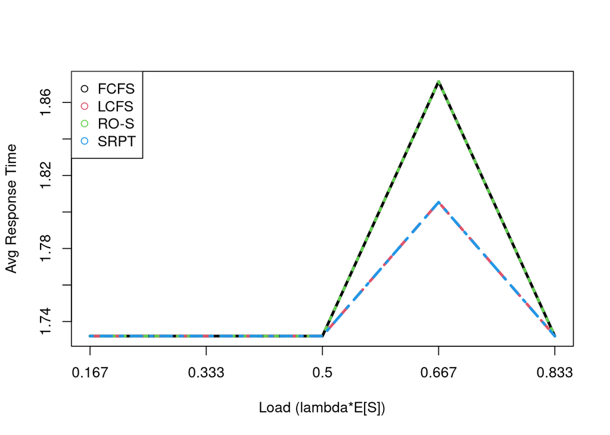

```
##      rho=0.167 rho=0.333  rho=0.5 rho=0.667 rho=0.833
## FCFS  1.732028  1.732028 1.732028  1.871468  1.732028
## LCFS  1.732028  1.732028 1.732028  1.805365  1.732028
## RO-S  1.732028  1.732028 1.732028  1.871468  1.732028
## SRPT  1.732028  1.732028 1.732028  1.805365  1.732028
```

```r
knitr::opts_chunk$set(echo = FALSE)

set.seed(11); # Set seed for reproducibility
N = 10; # number of jobs to simulate;
k = 3; # number of servers
mu=1;
Service=rexp(N,rate=mu); # Service times for the G/G/k/FCFS queue
plot_response_times(k, Service, 1/mu);
```

```
## Sim.  FCFS (rho= 0.17 ) completed. Little law verification:  0.1674 =N=lambda*R= 0.1654
## Sim.  LCFS (rho= 0.17 ) completed. Little law verification:  0.1674 =N=lambda*R= 0.1654
## Sim.  RO-S (rho= 0.17 ) completed. Little law verification:  0.1674 =N=lambda*R= 0.1654
## Sim.  SRPT (rho= 0.17 ) completed. Little law verification:  0.1674 =N=lambda*R= 0.1654
## Sim.  FCFS (rho= 0.33 ) completed. Little law verification:  0.3386 =N=lambda*R= 0.3312
## Sim.  LCFS (rho= 0.33 ) completed. Little law verification:  0.3386 =N=lambda*R= 0.3312
## Sim.  RO-S (rho= 0.33 ) completed. Little law verification:  0.3386 =N=lambda*R= 0.3312
## Sim.  SRPT (rho= 0.33 ) completed. Little law verification:  0.3386 =N=lambda*R= 0.3312
## Sim.  FCFS (rho= 0.5 ) completed. Little law verification:  0.4956 =N=lambda*R= 0.498
## Sim.  LCFS (rho= 0.5 ) completed. Little law verification:  0.4956 =N=lambda*R= 0.498
## Sim.  RO-S (rho= 0.5 ) completed. Little law verification:  0.4956 =N=lambda*R= 0.498
## Sim.  SRPT (rho= 0.5 ) completed. Little law verification:  0.4956 =N=lambda*R= 0.498
## Sim.  FCFS (rho= 0.67 ) completed. Little law verification:  0.6621 =N=lambda*R= 0.6702
## Sim.  LCFS (rho= 0.67 ) completed. Little law verification:  0.6618 =N=lambda*R= 0.6698
## Sim.  RO-S (rho= 0.67 ) completed. Little law verification:  0.662 =N=lambda*R= 0.67
## Sim.  SRPT (rho= 0.67 ) completed. Little law verification:  0.6616 =N=lambda*R= 0.6697
## Sim.  FCFS (rho= 0.83 ) completed. Little law verification:  0.8234 =N=lambda*R= 0.8453
## Sim.  LCFS (rho= 0.83 ) completed. Little law verification:  0.8215 =N=lambda*R= 0.8433
## Sim.  RO-S (rho= 0.83 ) completed. Little law verification:  0.8237 =N=lambda*R= 0.8456
## Sim.  SRPT (rho= 0.83 ) completed. Little law verification:  0.8214 =N=lambda*R= 0.8432
##
## Response time matrix:
##      rho=0.167 rho=0.333   rho=0.5 rho=0.667 rho=0.833
## FCFS 0.9926683 0.9935516 0.9959354  1.005295  1.014396
## LCFS 0.9926683 0.9935516 0.9959354  1.004704  1.011945
## RO-S 0.9926683 0.9935516 0.9959354  1.005048  1.014728
## SRPT 0.9926683 0.9935516 0.9959354  1.004507  1.011877
```

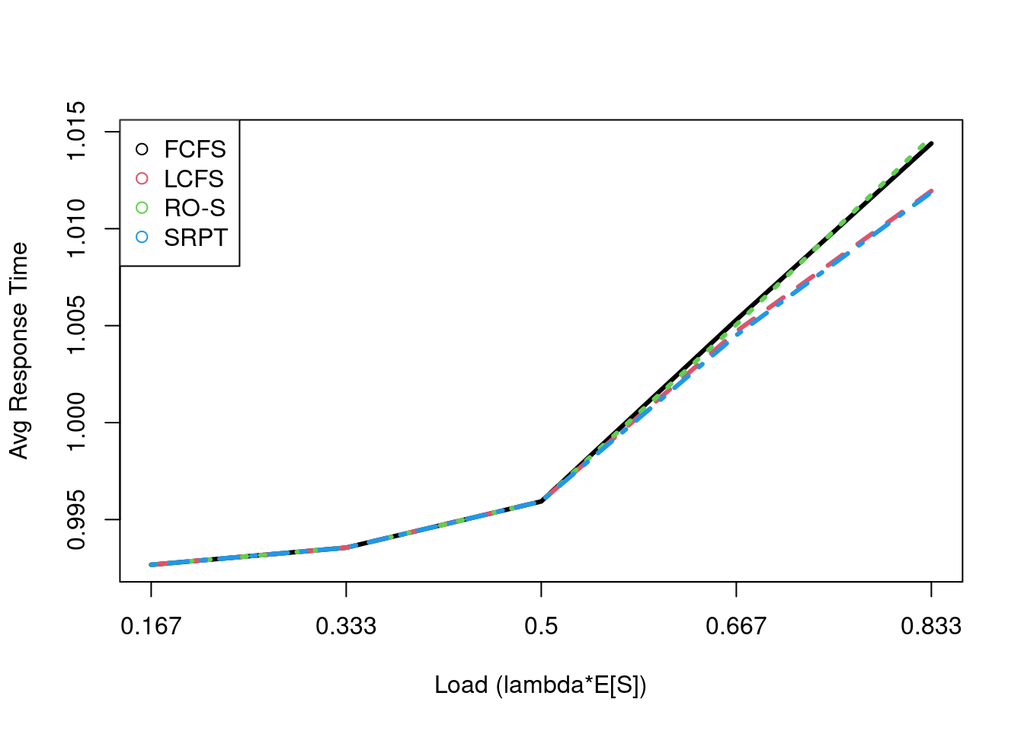

```
##      rho=0.167 rho=0.333   rho=0.5 rho=0.667 rho=0.833
## FCFS 0.9926683 0.9935516 0.9959354  1.005295  1.014396
## LCFS 0.9926683 0.9935516 0.9959354  1.004704  1.011945
## RO-S 0.9926683 0.9935516 0.9959354  1.005048  1.014728
## SRPT 0.9926683 0.9935516 0.9959354  1.004507  1.011877
```

Now, the goal is to compare the G/G/k queue with a G/G/1 queue having one server that is k times faster. For increasing values of the load (i.e., arrival rate divided by service rate) and k = 5, plot the ratio between the average response time obtained by a G/G/k/FCFS queue and the average response time obtained by a G/G/1/FCFS queue with a server that operates at speed k.

```
## Sim.  FCFS (rho= 0.17 ) completed. Little law verification:  0.2665 =N=lambda*R= 0.2908
## Sim.  LCFS (rho= 0.17 ) completed. Little law verification:  0.2665 =N=lambda*R= 0.2908
## Sim.  RO-S (rho= 0.17 ) completed. Little law verification:  0.2665 =N=lambda*R= 0.2908
## Sim.  SRPT (rho= 0.17 ) completed. Little law verification:  0.2665 =N=lambda*R= 0.2908
## Sim.  FCFS (rho= 0.33 ) completed. Little law verification:  0.6733 =N=lambda*R= 0.933
## Sim.  LCFS (rho= 0.33 ) completed. Little law verification:  0.7739 =N=lambda*R= 1.0724
## Sim.  RO-S (rho= 0.33 ) completed. Little law verification:  0.7739 =N=lambda*R= 1.0724
## Sim.  SRPT (rho= 0.33 ) completed. Little law verification:  0.6733 =N=lambda*R= 0.933
## Sim.  FCFS (rho= 0.5 ) completed. Little law verification:  2.473 =N=lambda*R= 2.2519
## Sim.  LCFS (rho= 0.5 ) completed. Little law verification:  2.6103 =N=lambda*R= 2.1456
## Sim.  RO-S (rho= 0.5 ) completed. Little law verification:  2.6651 =N=lambda*R= 2.3645
## Sim.  SRPT (rho= 0.5 ) completed. Little law verification:  2.0386 =N=lambda*R= 1.6779
## Sim.  FCFS (rho= 0.67 ) completed. Little law verification:  3.7278 =N=lambda*R= 4.3045
## Sim.  LCFS (rho= 0.67 ) completed. Little law verification:  3.9352 =N=lambda*R= 3.3128
## Sim.  RO-S (rho= 0.67 ) completed. Little law verification:  4.0012 =N=lambda*R= 4.3869
## Sim.  SRPT (rho= 0.67 ) completed. Little law verification:  3.189 =N=lambda*R= 2.6891
## Sim.  FCFS (rho= 0.83 ) completed. Little law verification:  3.6731 =N=lambda*R= 5.7376
## Sim.  LCFS (rho= 0.83 ) completed. Little law verification:  4.146 =N=lambda*R= 4.136
## Sim.  RO-S (rho= 0.83 ) completed. Little law verification:  3.237 =N=lambda*R= 3.6924
## Sim.  SRPT (rho= 0.83 ) completed. Little law verification:  3.1352 =N=lambda*R= 3.1556
##
## Response time matrix:
##      rho=0.167 rho=0.333  rho=0.5 rho=0.667 rho=0.833
## FCFS  1.744986  2.798935 4.503814  6.456718  6.885179
## LCFS  1.744986  3.217186 4.291288  4.969159  4.963217
## RO-S  1.744986  3.217186 4.728971  6.580372  4.430825
## SRPT  1.744986  2.798935 3.355746  4.033617  3.786693
```

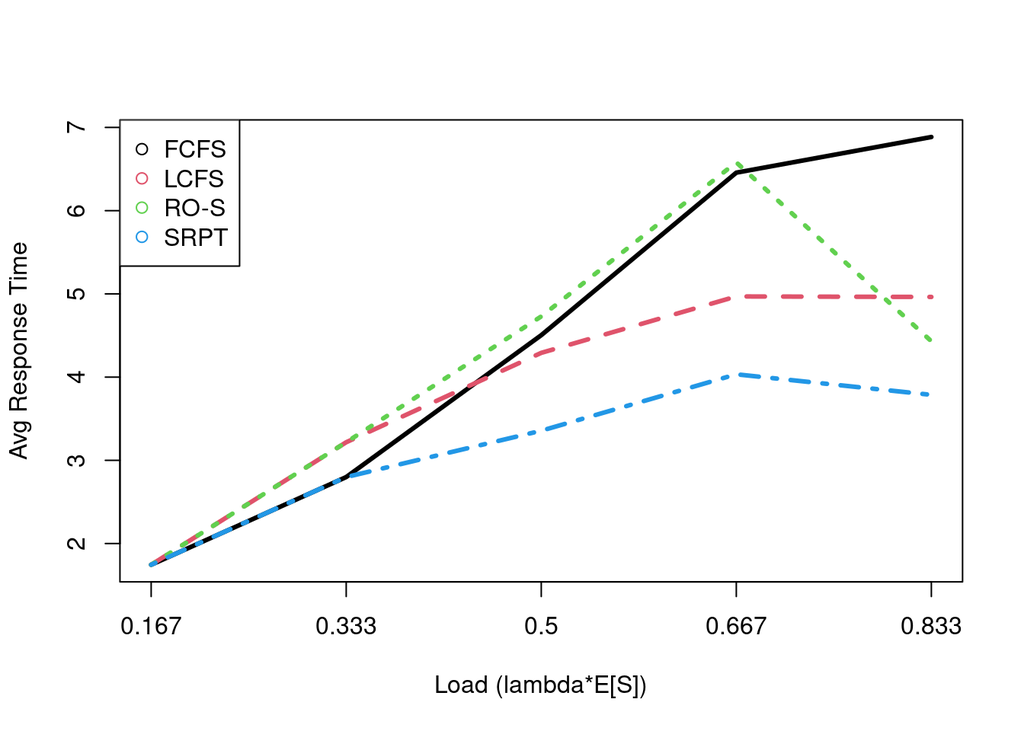

```
## Sim.  FCFS (rho= 0.17 ) completed. Little law verification:  0.0577 =N=lambda*R= 0.0577
## Sim.  LCFS (rho= 0.17 ) completed. Little law verification:  0.0577 =N=lambda*R= 0.0577
## Sim.  RO-S (rho= 0.17 ) completed. Little law verification:  0.0577 =N=lambda*R= 0.0577
## Sim.  SRPT (rho= 0.17 ) completed. Little law verification:  0.0577 =N=lambda*R= 0.0577
## Sim.  FCFS (rho= 0.33 ) completed. Little law verification:  0.132 =N=lambda*R= 0.1245
## Sim.  LCFS (rho= 0.33 ) completed. Little law verification:  0.132 =N=lambda*R= 0.1245
## Sim.  RO-S (rho= 0.33 ) completed. Little law verification:  0.132 =N=lambda*R= 0.1245
## Sim.  SRPT (rho= 0.33 ) completed. Little law verification:  0.132 =N=lambda*R= 0.1245
## Sim.  FCFS (rho= 0.5 ) completed. Little law verification:  0.1574 =N=lambda*R= 0.1732
## Sim.  LCFS (rho= 0.5 ) completed. Little law verification:  0.1574 =N=lambda*R= 0.1732
## Sim.  RO-S (rho= 0.5 ) completed. Little law verification:  0.1574 =N=lambda*R= 0.1732
## Sim.  SRPT (rho= 0.5 ) completed. Little law verification:  0.1574 =N=lambda*R= 0.1732
## Sim.  FCFS (rho= 0.67 ) completed. Little law verification:  0.3478 =N=lambda*R= 0.2966
## Sim.  LCFS (rho= 0.67 ) completed. Little law verification:  0.3478 =N=lambda*R= 0.2966
## Sim.  RO-S (rho= 0.67 ) completed. Little law verification:  0.3478 =N=lambda*R= 0.2966
## Sim.  SRPT (rho= 0.67 ) completed. Little law verification:  0.3478 =N=lambda*R= 0.2966
## Sim.  FCFS (rho= 0.83 ) completed. Little law verification:  1.2682 =N=lambda*R= 0.5722
## Sim.  LCFS (rho= 0.83 ) completed. Little law verification:  1.0925 =N=lambda*R= 0.4929
## Sim.  RO-S (rho= 0.83 ) completed. Little law verification:  1.0925 =N=lambda*R= 0.4929
## Sim.  SRPT (rho= 0.83 ) completed. Little law verification:  1.0925 =N=lambda*R= 0.4929
##
## Response time matrix:
##      rho=0.167 rho=0.333  rho=0.5 rho=0.667 rho=0.833
## FCFS  1.732028   1.86707 1.732028   2.22427  3.433034
## LCFS  1.732028   1.86707 1.732028   2.22427  2.957440
## RO-S  1.732028   1.86707 1.732028   2.22427  2.957440
## SRPT  1.732028   1.86707 1.732028   2.22427  2.957440
```

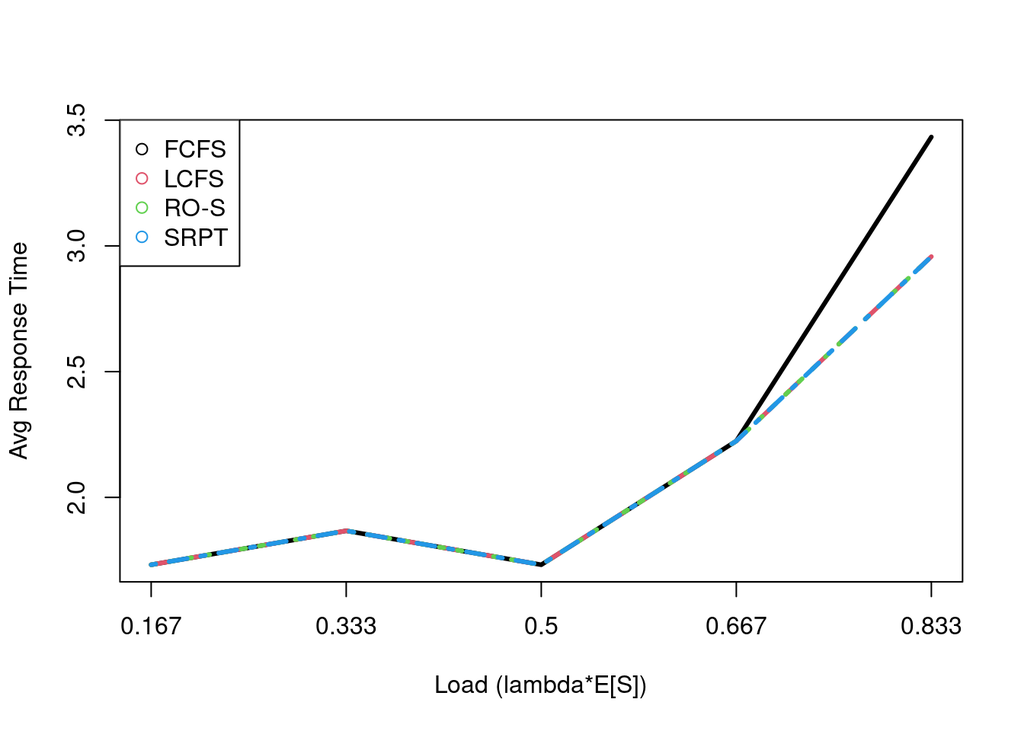

The 2 different plot shows the average response time for the different scheduling disciplines for the G/G/k/FCFS queue and the G/G/1/FCFS queue with a server that operates at speed k. We can see that the average response time for the G/G/k/FCFS queue is always higher than the average response time for the G/G/1/FCFS queue with a server that operates at speed k. This is due to the fact that we have not enough jobs to keep all the servers busy in the G/G/k/FCFS queue. So the G/G/1 queue with a server that operates at speed k is always faster than the G/G/k queue for the considered load.

Now, let’s plot the ratio between the average response time obtained by a G/G/k/FCFS queue and the average response time obtained by a G/G/1/FCFS queue with a server that operates at speed k.

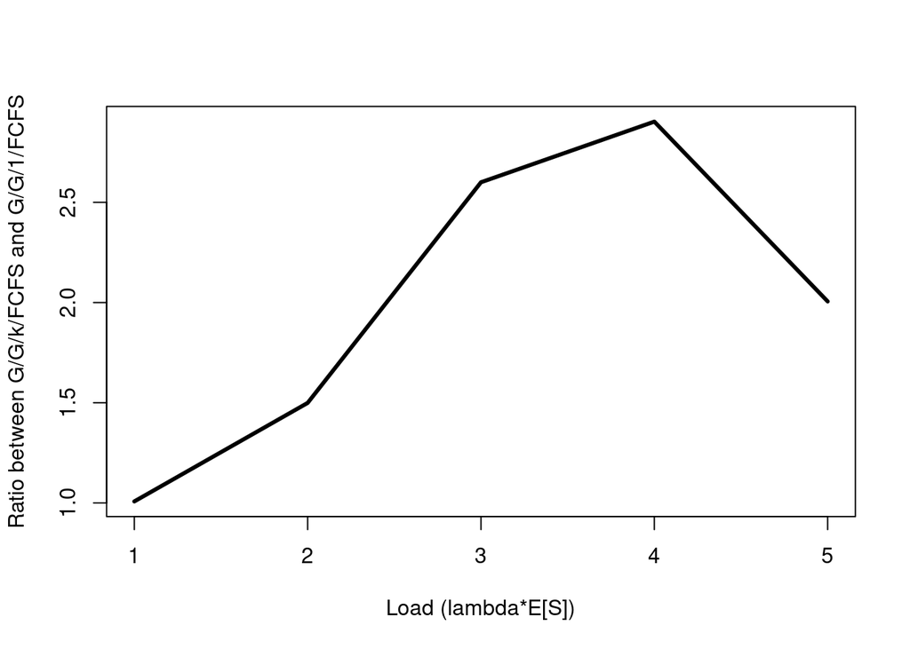

### References

[1] Schrage, Linus. “A Proof of the Optimality of the Shortest Remaining Processing Time Discipline.” Operations Research, vol. 16, no. 3, 1968, pp. 687–90.